# DATA602

Author

Ana Collado

# The Paycheck Protection Program: An Examination of SBA Released Data in Python

## The Context:

In the aftermath of COVID, businesses in need of help applied for SBA backed loans under the Paycheck Protection Program (PPP).[^1] The loans were intended to be forgiven if the business met specific criteria.[^2] The program was extended, in the form of a second round– abbreviated as PPS where business could apply for *more* support.

As the PPP program launched, the internet boomed with rumors of businesses applying for loans (knowing they’d be forgiven) and creating job posts (with ridiculous requirements) in order to meet one of the forgiveness criteria.

The Small Business Administration, with assistance of The Office of Inspector General, released a report in 2023 informing the public, the SBA had disbursed a total of $200 billion to fraudulent claims. While the report was exclusively about blatant falsification of details (false EIN, false addresses, etc). The SBA released a public list of all companies that applied and received PPP loan funds in 2020. Updated regularly– with its last update being on October 24th 2024.

While the dataset is quite large, it could prove impossible to truly say whether there is more fraud than the report outlined– even if the whispers of the internet could be true. Yet, in the spirit of examining the businesses that submitted claims, and with an abundance of options I’ll focus on examining the Rural/Urban Indicator and whether or not there is a significant difference in loan forgiveness amount depending on classification.

Two separate analyses were performed using R and the results were as follows.

1) There **was a significant difference** in PPP loan forgiveness contingent on the proportion of missing values within the application. Answering all the questions in the PPP Loan Forgiveness application seemed to significantly impact the proportion of forgiveness of the loan.

[figure not shown]

*(p-value at approximately 0, and a 95% confidence interval ranging from 7380.743 to 8022.796) We **reject the null hypothesis**)*

2) There was **not a significant difference** in PPP loan forgiveness between claims from businesses classified as being in a HubZone (at economic disadvantage) vs businessess that were not in a HubZone.

[figure not shown]

*“With a P value at 0.16 at the alpha level of 0.05– I am 95% confident that the businesses who are part of a HubZone have an average difference in the proportion forgiven of their PPP Loan between -0.0044 and 0.000731. The interval includes zero, suggesting there is not a significant difference in proportion of loan forgiven. We fail to reject the null hypothesis.”*

## The Data:

##### Load Libraries

```python
import pandas as pd
import numpy as np
import scipy.stats as stats
import matplotlib.pyplot as plt
import seaborn as sns
```

##### Load Data

```python
dataP1 = pd.read_csv('dataP1.csv', index_col=0, encoding= 'latin1')
```

The dataset has 2,700,000 data points. Due to computational limitations, I can’t load the SBA Dataset in its entirety.

```python
dataP1.info()
```

```
<class 'pandas.core.frame.DataFrame'>
Index: 2700000 entries, 3509338307 to 9205648402
Data columns (total 52 columns):
 #   Column                       Dtype
---  ------                       -----
 0   DateApproved                 object
 1   SBAOfficeCode                float64
 2   ProcessingMethod             object
 3   BorrowerName                 object
 4   BorrowerAddress              object
 5   BorrowerCity                 object
 6   BorrowerState                object
 7   BorrowerZip                  object
 8   LoanStatusDate               object
 9   LoanStatus                   object
```

[output cut: 44 more lines]

## NA Values

As it is with any survey, form, or application, there are plenty of NA values by way of skipped questions. The PPPL Forgiveness forms were submitted by the borrower or lender. The form in part could appear prefilled for borrowers if the Lender had previously input the borrower details.

```python
dataP1_na_values = dataP1.isna()
dataP1_na_chart= pd.DataFrame(dataP1_na_values.value_counts())
```

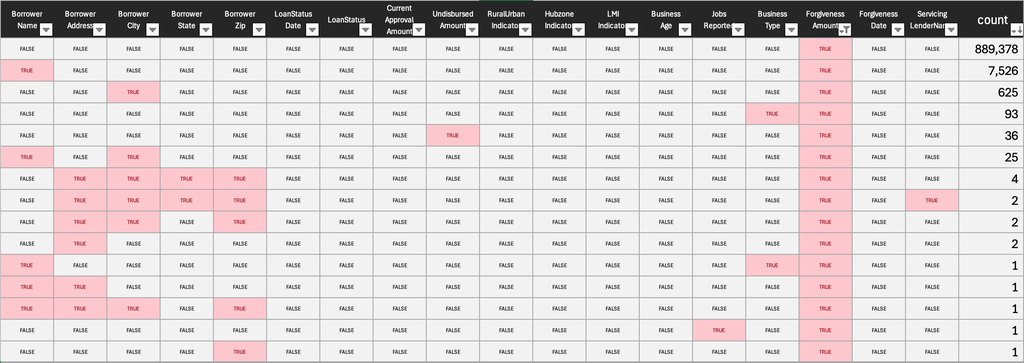

Descending_NA_Chart.png

```python
####Histogram Showing count of True(NA values) and False (Non NA Values) Before Dropping NA
na_count = dataP1['ForgivenessAmount'].isna().value_counts()
na_count.plot(kind='bar', color='lightseagreen', rot=90)

# Customize plot aesthetics
plt.gca().spines[['top', 'right']].set_visible(False)
plt.title("NA Values in ForgivenessAmount Column of SBA PPP Loan Dataset")
plt.ylabel("Count of NA Values")
plt.xlabel("ForgivenessAmount is NA? (True/False)")

# Save and display the plot
plt.savefig("ForgivenessAmount_na_chart.png")
plt.show()
```

[figure not shown]

### Changing the Data Types

`ProcessingMethod`, `LMIIndicator`, `RuralUrbanIndicator`, `LoanStatus`, and `ProcessingMethod` are categorical. `BorrowerState` and `BorrowerName` will be string values, and `ForgivenessAmount` will remain as float.

```python
category_columns = ['ProcessingMethod','LMIIndicator', 'RuralUrbanIndicator', 'LoanStatus']

dataP1[category_columns] = dataP1[category_columns].astype('category')

print(dataP1.info())

analysis= pd.DataFrame(dataP1, columns= ['RuralUrbanIndicator', 'CurrentApprovalAmount','ForgivenessAmount'])
analysis.head()
```

```
<class 'pandas.core.frame.DataFrame'>
Index: 2700000 entries, 3509338307 to 9205648402
Data columns (total 52 columns):
 #   Column                       Dtype
---  ------                       -----
 0   DateApproved                 object
 1   SBAOfficeCode                float64
 2   ProcessingMethod             category
 3   BorrowerName                 object
 4   BorrowerAddress              object
 5   BorrowerCity                 object
 6   BorrowerState                object
 7   BorrowerZip                  object
 8   LoanStatusDate               object
 9   LoanStatus                   category
```

[output cut: 45 more lines]

| LoanNumber | RuralUrbanIndicator | CurrentApprovalAmount | ForgivenessAmount |
| --- | --- | --- | --- |
| 3509338307 | U | 149360.60 | 150775.38 |
| 5375617707 | U | 148440.00 | 150083.01 |
| 9677497701 | U | 140081.78 | 141920.11 |
| 9547167709 | U | 136520.96 | 137747.78 |
| 8885207205 | U | 130600.00 | 131876.98 |

We should narrow down the columns that will be relevant for this analysis. To find a significant difference in PPP loan forgiveness amount proportion, between businesses classified as Rural and those classified as Urban, we’ll need `RuralUrbanIndicator` column. Our examination will include the first ans second round of the PPP but we’ll need `Processing Method` to groupby and we’ll ofcourse need `ForgivenessAmount`column.

# Hypothesis Testing

### Preparing for Hypothesis Test

```python
''' Calculating the Proportion of Forgiveness because Rural ocunt and Urban counts are not the same. This way the proportions are normalized. '''
#Proportion
analysis.loc[:,'ProportionForgiven'] = analysis['ForgivenessAmount'] / analysis['CurrentApprovalAmount']

#Taking a Look again
analysis.head()

#Finding Mean proportions for each group
analysis[['RuralUrbanIndicator', 'ProportionForgiven']].groupby('RuralUrbanIndicator').mean()
```

| RuralUrbanIndicator | ProportionForgiven |
| --- | --- |
| R | 1.004804 |
| U | 1.001519 |

### Hypothesis Statement

- *Null Hypothesis:*

  There is no significant difference in the average loan forgiveness proportion between businesses categorized as ‘Urban’ and businesses categorized as ‘Rural’.
- *Alt Hypothesis:*

  There is a significant difference in the average loan forgiveness proportion between businesses categorized as ‘Urban’ and businesses categorized as ‘Rural’.

# Calculate observed difference

```python
mean_R = analysis.loc[analysis['RuralUrbanIndicator'] == 'R', 'ProportionForgiven'].mean()
mean_U = analysis.loc[analysis['RuralUrbanIndicator'] == 'U', 'ProportionForgiven'].mean()
obs_diff = mean_R - mean_U
print(f"Observed Difference in Means: {obs_diff}")
```

```
Observed Difference in Means: 0.0032846496765595035
```

### NULL Distribution

```python
print(analysis.isna().sum())

analysis.dropna(inplace=True)

from sklearn.utils import shuffle
```

```
RuralUrbanIndicator           0
CurrentApprovalAmount         0
ForgivenessAmount        239767
ProportionForgiven       239767
dtype: int64
```

# Convert to NumPy arrays[^3]

```python
proportion_forgiven = np.array(analysis['ProportionForgiven'])
rural_urban_indicator = np.array(analysis['RuralUrbanIndicator'])
```

# Observed difference in means

```python
group_R = proportion_forgiven[rural_urban_indicator == 'R']
group_U = proportion_forgiven[rural_urban_indicator == 'U']
observed_diff = np.mean(group_R) - np.mean(group_U)
```

# Permutation test

```python
n_permutations = 10000
perm_diffs = []

for _ in range(n_permutations):
  shuffled_labels = shuffle(rural_urban_indicator)
  perm_group_R = proportion_forgiven[shuffled_labels == 'R']
  perm_group_U = proportion_forgiven[shuffled_labels == 'U']
  perm_diff = np.mean(perm_group_R) - np.mean(perm_group_U)
  perm_diffs.append(perm_diff)
```

# Compute p-value

```python
perm_diffs = np.array(perm_diffs)
rounded_perm_diffs= np.round(perm_diffs, decimals= 4)
p_value = np.mean(np.abs(perm_diffs) >= np.abs(observed_diff))


print(f"Observed Difference: {observed_diff}")
print(f"P-Value: {p_value}")
```

```
Observed Difference: 0.0032846496765595035
P-Value: 0.0
```

We’ve got a p value of 0 and an observed difference of 0.0032. So far we’re rejecting the null hypothesis that there is no significant difference in PPP loan forgiveness amount between businesses classified as Urban and bisunesses classified as Rural. There seems to be a significant difference but lets compute the confidence interval.[^4]

Because we did permutation, our confidence interval will be alot easier to do because we will use percentiles.

```python
lower = np.percentile(rounded_perm_diffs, 2.5)
upper = np.percentile(rounded_perm_diffs, 97.5)


print(f"95% Confidence Interval: [{lower}, {upper}]")
```

```
95% Confidence Interval: [-0.0002, 0.0002]
```

My initial calculations returned a p-value of 0 and a confidence interval that included zero, as you can see below:

[figure not shown]

The P value of approximately zero which indicated something was not right. I felt we might be better served by increasing the permutations for the sake of accuracy. I increased my permutations from 1000 to 10,000. When I recomputed the values, I again saw the same.

```python
#null
plt.hist(perm_diffs, bins=100, color='lightseagreen', alpha=0.7, label='Null Distribution')

#obs
plt.axvline(observed_diff, color='darkblue', linestyle='solid', linewidth=2, label=f"Observed Diff: {observed_diff:.6f}")

#ci
plt.axvline(lower, color='darkcyan', linestyle='dotted', linewidth=1, label="95% CI Lower")
plt.axvline(upper, color='darkcyan', linestyle='dotted', linewidth=1, label="95% CI Upper")

plt.title("Null Distribution")
plt.xlabel("Difference in Means")
plt.ylabel("Frequency")
plt.legend()
plt.show()
```

[figure not shown]

The plot shows that the distribution is visibly narrow, close to normal I believe, as it seems bell shaped. However, everything is so close together the observed difference which is also close to zero seems incredibly far away. Notice the scale on the x axis is incredibly tiny. I’m not sure what can be concluded with this data. At the very least we can say there is a significant observed difference!

## Footnotes

[^1]: Paycheck Protection Program Overview:

    https://home.treasury.gov/system/files/136/PPP%20--%20Overview.pdf
[^2]: Business Loan Program Temporary Changes; Paycheck Protection Program-Requirements-Loan Forgiveness:  
    https://www.federalregister.gov/documents/2020/06/01/2020-11536/business-loan-program-temporary-changes-paycheck-protection-program-requirements-loan-forgiveness
[^3]: Computer couldn’t handle the permutations done with slicing, did it with np arrays instead https://stackoverflow.com/questions/21567842/is-there-a-performance-difference-between-numpy-and-pandas
[^4]: Confidence interval after permutation:

    https://medium.com/@whystudying/resampling-with-python-permutation-test-19421dc38dac